# Final project_Group17_houseprice

Divyesh, Raj Charan, Preetham

2023-11-29

libraries:

```r
library(tidyverse) #for data manipulation, transformation, visualization, and modeling
```

```r
library(ggplot2) #for creating elegant and customizable visualizations in R.
library(tigerstats) #descriptive statistics, probability distributions, hypothesis testing.
library(MASS) #multivariate statistics, including linear and nonlinear regression.
library(MLmetrics) #providing a variety of metrics for regression.
```

Importing Data:

```r
houseprice <- read.csv("C:/Users/Divyesh/Downloads/data.csv")
```

Observations:

```r
dim(houseprice)
```

```
## [1] 4600   18
```

```r
head(houseprice)
```

```
##                  date   price bedrooms bathrooms sqft_living sqft_lot floors
## 1 2014-05-02 00:00:00  313000        3      1.50        1340     7912    1.5
## 2 2014-05-02 00:00:00 2384000        5      2.50        3650     9050    2.0
## 3 2014-05-02 00:00:00  342000        3      2.00        1930    11947    1.0
## 4 2014-05-02 00:00:00  420000        3      2.25        2000     8030    1.0
## 5 2014-05-02 00:00:00  550000        4      2.50        1940    10500    1.0
## 6 2014-05-02 00:00:00  490000        2      1.00         880     6380    1.0
##   waterfront view condition sqft_above sqft_basement yr_built yr_renovated
## 1          0    0         3       1340             0     1955         2005
## 2          0    4         5       3370           280     1921            0
## 3          0    0         4       1930             0     1966            0
## 4          0    0         4       1000          1000     1963            0
## 5          0    0         4       1140           800     1976         1992
## 6          0    0         3        880             0     1938         1994
##                     street      city statezip country
## 1     18810 Densmore Ave N Shoreline WA 98133     USA
## 2          709 W Blaine St   Seattle WA 98119     USA
## 3 26206-26214 143rd Ave SE      Kent WA 98042     USA
## 4          857 170th Pl NE  Bellevue WA 98008     USA
## 5        9105 170th Ave NE   Redmond WA 98052     USA
## 6           522 NE 88th St   Seattle WA 98115     USA
```

DataTypes of the variables:

```r
str(houseprice)
```

```
## 'data.frame':    4600 obs. of  18 variables:
##  $ date         : chr  "2014-05-02 00:00:00" "2014-05-02 00:00:00" "2014-05-02 00:00:00" "2014-05-02 00:00:00" ...
##  $ price        : num  313000 2384000 342000 420000 550000 ...
##  $ bedrooms     : num  3 5 3 3 4 2 2 4 3 4 ...
##  $ bathrooms    : num  1.5 2.5 2 2.25 2.5 1 2 2.5 2.5 2 ...
##  $ sqft_living  : int  1340 3650 1930 2000 1940 880 1350 2710 2430 1520 ...
##  $ sqft_lot     : int  7912 9050 11947 8030 10500 6380 2560 35868 88426 6200 ...
##  $ floors       : num  1.5 2 1 1 1 1 1 2 1 1.5 ...
##  $ waterfront   : int  0 0 0 0 0 0 0 0 0 0 ...
##  $ view         : int  0 4 0 0 0 0 0 0 0 0 ...
##  $ condition    : int  3 5 4 4 4 3 3 3 4 3 ...
##  $ sqft_above   : int  1340 3370 1930 1000 1140 880 1350 2710 1570 1520 ...
##  $ sqft_basement: int  0 280 0 1000 800 0 0 0 860 0 ...
##  $ yr_built     : int  1955 1921 1966 1963 1976 1938 1976 1989 1985 1945 ...
##  $ yr_renovated : int  2005 0 0 0 1992 1994 0 0 0 2010 ...
##  $ street       : chr  "18810 Densmore Ave N" "709 W Blaine St" "26206-26214 143rd Ave SE" "857 170th Pl NE" ...
##  $ city         : chr  "Shoreline" "Seattle" "Kent" "Bellevue" ...
##  $ statezip     : chr  "WA 98133" "WA 98119" "WA 98042" "WA 98008" ...
##  $ country      : chr  "USA" "USA" "USA" "USA" ...
```

Check for missing values:

```r
sum(is.na(houseprice))
```

```
## [1] 0
```

Check for duplicate values:

```r
sum(duplicated(houseprice))
```

```
## [1] 0
```

Summary:

```r
summary(houseprice)
```

```
##      date               price             bedrooms       bathrooms
##  Length:4600        Min.   :       0   Min.   :0.000   Min.   :0.000
##  Class :character   1st Qu.:  322875   1st Qu.:3.000   1st Qu.:1.750
##  Mode  :character   Median :  460943   Median :3.000   Median :2.250
##                     Mean   :  551963   Mean   :3.401   Mean   :2.161
##                     3rd Qu.:  654962   3rd Qu.:4.000   3rd Qu.:2.500
##                     Max.   :26590000   Max.   :9.000   Max.   :8.000
##   sqft_living       sqft_lot           floors        waterfront
##  Min.   :  370   Min.   :    638   Min.   :1.000   Min.   :0.000000
##  1st Qu.: 1460   1st Qu.:   5001   1st Qu.:1.000   1st Qu.:0.000000
##  Median : 1980   Median :   7683   Median :1.500   Median :0.000000
##  Mean   : 2139   Mean   :  14852   Mean   :1.512   Mean   :0.007174
##  3rd Qu.: 2620   3rd Qu.:  11001   3rd Qu.:2.000   3rd Qu.:0.000000
##  Max.   :13540   Max.   :1074218   Max.   :3.500   Max.   :1.000000
##       view          condition       sqft_above   sqft_basement
##  Min.   :0.0000   Min.   :1.000   Min.   : 370   Min.   :   0.0
##  1st Qu.:0.0000   1st Qu.:3.000   1st Qu.:1190   1st Qu.:   0.0
##  Median :0.0000   Median :3.000   Median :1590   Median :   0.0
##  Mean   :0.2407   Mean   :3.452   Mean   :1827   Mean   : 312.1
##  3rd Qu.:0.0000   3rd Qu.:4.000   3rd Qu.:2300   3rd Qu.: 610.0
##  Max.   :4.0000   Max.   :5.000   Max.   :9410   Max.   :4820.0
##     yr_built     yr_renovated       street              city
##  Min.   :1900   Min.   :   0.0   Length:4600        Length:4600
##  1st Qu.:1951   1st Qu.:   0.0   Class :character   Class :character
##  Median :1976   Median :   0.0   Mode  :character   Mode  :character
##  Mean   :1971   Mean   : 808.6
##  3rd Qu.:1997   3rd Qu.:1999.0
##  Max.   :2014   Max.   :2014.0
##    statezip           country
##  Length:4600        Length:4600
##  Class :character   Class :character
##  Mode  :character   Mode  :character
##
##
##
```

```
                                         Exploratory Data Analysis
```

Histograms:

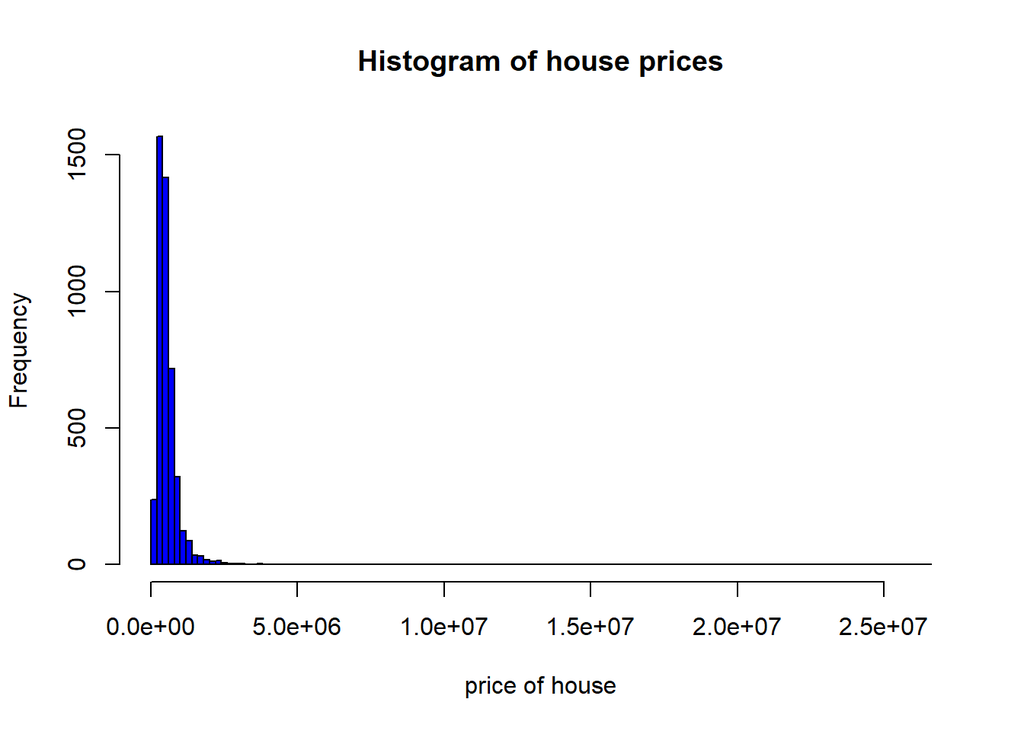

```r
hist(houseprice$price, main = "Histogram of house prices",
 xlab = "price of house",
 ylab = "Frequency",
 col = "blue",
 border = "black",
 breaks=100)
```

This histogram shows the distribution of price of houses in the dataset. The x-axis represents the price of house, while the y-axis shows the frequency of each value or the count of individuals in each bin.

From the plot, we can see that most of the house prices in the dataset are in the range of 0 to 1,000,000. The frequency of occurrence decreases as the price increase, which is expected as higher price values are less common.

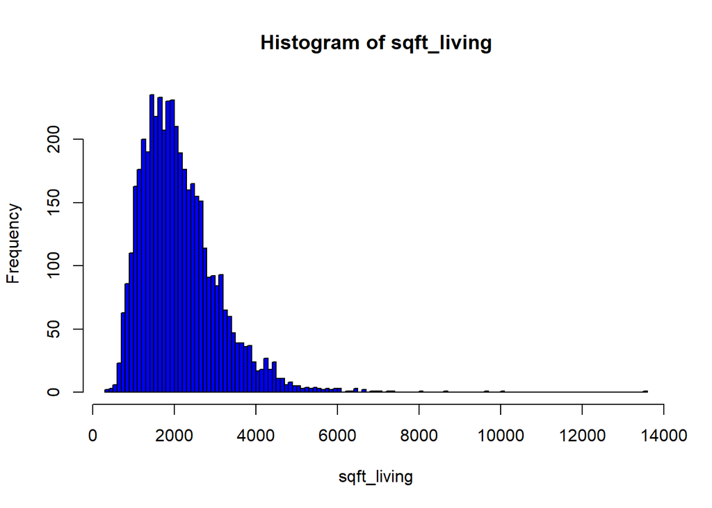

```r
hist(houseprice$sqft_living
     , breaks = 100, col = "blue", border = "black",
 main = "Histogram of sqft_living", xlab = "sqft_living")
```

The histogram represents the distribution of the variable sqft_living in the houseprice dataset. The x-axis represents the range of sqft_living values and the y-axis represents the frequency of occurrence of the income values.

From the histogram, we can see that most of the house with sqft of their living area is between 0 to 6000 sqft. The frequency of occurrence decreases as the sqft values increase, which is expected as higher sqft_living values are less in common.

Boxplot:

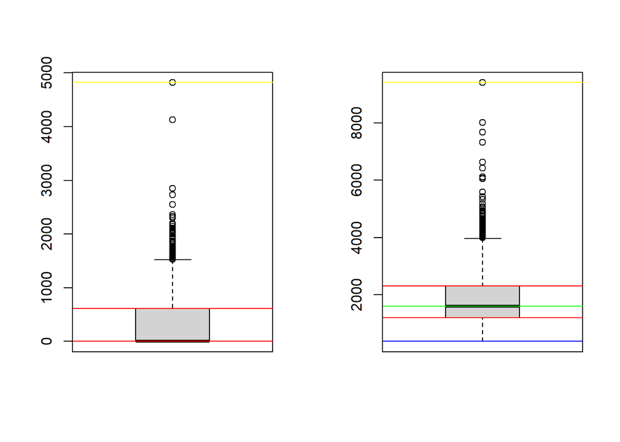

```r
par(mfrow = c(1, 2))
boxplot(houseprice$sqft_basement)
abline(h = min(houseprice$sqft_basement), col = "Blue")
abline(h = max(houseprice$sqft_basement), col = "Yellow")
abline(h = median(houseprice$sqft_basement), col = "Green")
abline(h = quantile(houseprice$sqft_basement, c(0.25, 0.75)), col = "Red")

boxplot(houseprice$sqft_above)
abline(h = min(houseprice$sqft_above), col = "Blue")
abline(h = max(houseprice$sqft_above), col = "Yellow")
abline(h = median(houseprice$sqft_above), col = "Green")
abline(h = quantile(houseprice$sqft_above, c(0.25, 0.75)), col = "Red")
```

Barplot:

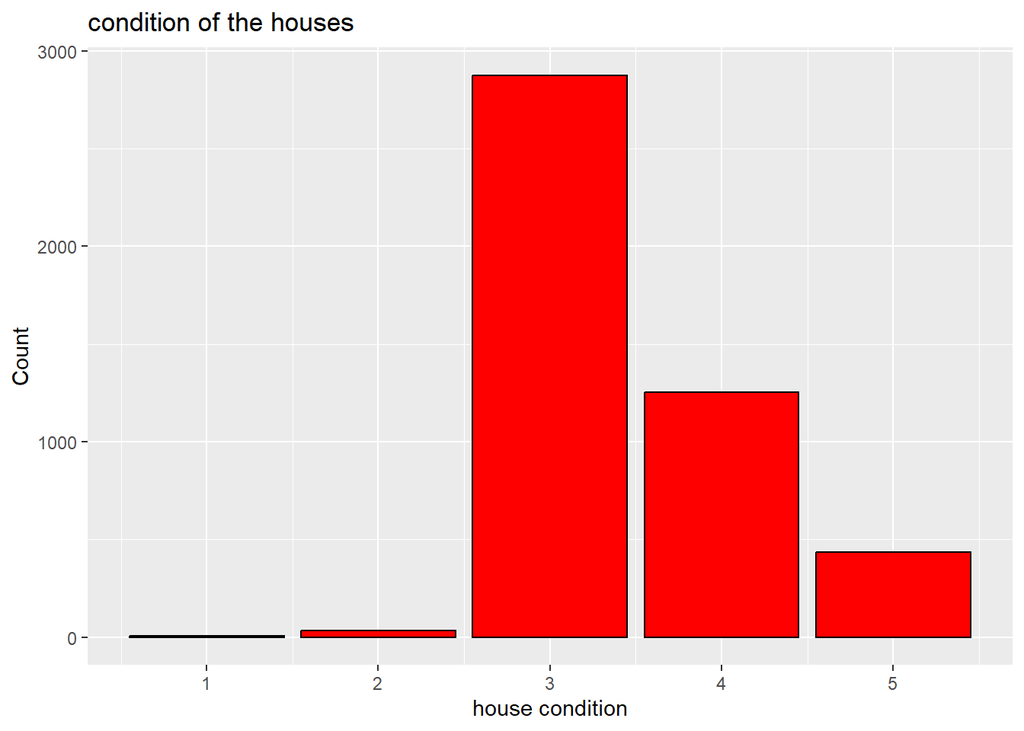

```r
ggplot(houseprice, aes(x = condition)) +
 geom_bar(fill = "red", color = "black") +
 labs(x = "house condition", y = "Count", title = "condition of the houses")
```

This plot gives the no of houses in a particular level of condition.

x-axis shows house condition level, while the y-axis represents the count of houses in each condition level category.

From the graph we can see that most of the houses have 3rd level condition.

Overlays:

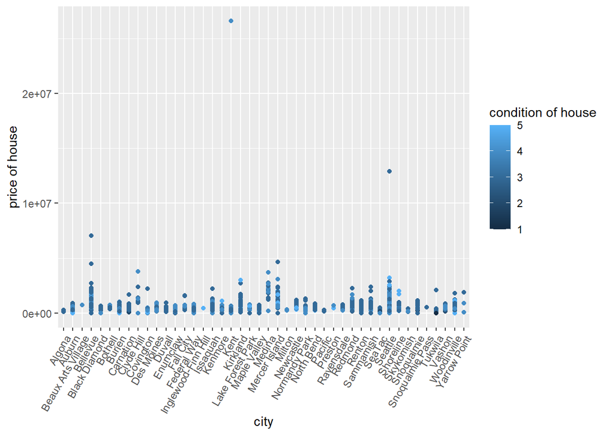

```r
ggplot(houseprice, aes(x = city, y = price, color = condition)) +
 geom_point() +
 labs(x = "city", y = "price of house", color = "condition of house")+
  theme(axis.text.x = element_text(angle = 60, hjust = 1))
```

```
                                            Hypothesis testing
```

1. hypothesis test for ratio of the variances of two populations.(F- test)

Null hypothesis: The ratio of the variances of the two populations(condition of houses with 5 and 4) is equal to 1.

Alternative hypothesis: The ratio of the variances of the two populations is not equal to 1.

```r
good <- subset(houseprice, condition == "5")
average <- subset(houseprice, condition == "4")
var.test(good$price, average$price)
```

```
##
##  F test to compare two variances
##
## data:  good$price and average$price
## F = 0.27917, num df = 434, denom df = 1251, p-value < 2.2e-16
## alternative hypothesis: true ratio of variances is not equal to 1
## 95 percent confidence interval:
##  0.2398936 0.3267991
## sample estimates:
## ratio of variances
##          0.2791742
```

As P value is much less than alpha(0.05). we reject the null hypothesis that the ratio of the variances of the two populations is equal to 1. Therefore, we conclude that the variances of the condition of houses with 4 and 5 are not equal.

2. Choosing the appropriate test to make a conclusion:

Since we have rejected the null hypothesis that the variances of the two populations are equal, we should use a Welch’s t-test to compare the means of the two populations, since it does not assume equal variances.

Null hypothesis: There is no significant difference in means of prices between levels of conditions 4 and 5.

Alternative hypothesis: There is a significant difference in means of prices between levels of conditions 4 and 5.

```r
t.test(good$price, average$price, conf.level = 0.95)
```

```
##
##  Welch Two Sample t-test
##
## data:  good$price and average$price
## t = 3.3479, df = 1422.2, p-value = 0.0008357
## alternative hypothesis: true difference in means is not equal to 0
## 95 percent confidence interval:
##   42811.64 163976.44
## sample estimates:
## mean of x mean of y
##  637041.3  533647.3
```

We have alpha i.e., Confidence Interal as 95% (Default)

From the t test result it is clear that p-value is much lesser the alpha value (0.05), Therefore we reject the Null Hypothesis and conclude that there is a significant difference in means of the prices between levels of conditions 4 and 5.

```
                                                Linear Regression
```

```r
cor(houseprice[,2:14])
```

```
##                     price     bedrooms   bathrooms sqft_living     sqft_lot
## price          1.00000000  0.200336289  0.32710992  0.43041003  0.050451295
## bedrooms       0.20033629  1.000000000  0.54591993  0.59488406  0.068819355
## bathrooms      0.32710992  0.545919926  1.00000000  0.76115370  0.107837479
## sqft_living    0.43041003  0.594884059  0.76115370  1.00000000  0.210538454
## sqft_lot       0.05045130  0.068819355  0.10783748  0.21053845  1.000000000
## floors         0.15146080  0.177894903  0.48642757  0.34485027  0.003749750
## waterfront     0.13564832 -0.003482794  0.07623225  0.11761601  0.017241054
## view           0.22850417  0.111028000  0.21196025  0.31100944  0.073906741
## condition      0.03491454  0.025079856 -0.11999434 -0.06282598  0.000558114
## sqft_above     0.36756960  0.484705342  0.68991841  0.87644325  0.216454651
## sqft_basement  0.21042657  0.334165246  0.29802018  0.44720554  0.034842303
## yr_built       0.02185683  0.142461041  0.46349768  0.28777522  0.050706346
## yr_renovated  -0.02877365 -0.061081566 -0.21588624 -0.12281688 -0.022730309
##                    floors   waterfront        view    condition  sqft_above
## price          0.15146080  0.135648322  0.22850417  0.034914537  0.36756960
## bedrooms       0.17789490 -0.003482794  0.11102800  0.025079856  0.48470534
## bathrooms      0.48642757  0.076232247  0.21196025 -0.119994341  0.68991841
## sqft_living    0.34485027  0.117616006  0.31100944 -0.062825979  0.87644325
## sqft_lot       0.00374975  0.017241054  0.07390674  0.000558114  0.21645465
## floors         1.00000000  0.022023786  0.03121095 -0.275013395  0.52281374
## waterfront     0.02202379  1.000000000  0.36093476  0.000352282  0.07891113
## view           0.03121095  0.360934761  1.00000000  0.063077281  0.17432671
## condition     -0.27501339  0.000352282  0.06307728  1.000000000 -0.17819634
## sqft_above     0.52281374  0.078911129  0.17432671 -0.178196344  1.00000000
## sqft_basement -0.25550982  0.097500955  0.32160180  0.200632350 -0.03872299
## yr_built       0.46748066 -0.023563444 -0.06446506 -0.399698234  0.40853521
## yr_renovated  -0.23399567  0.008624620  0.02296700 -0.186818414 -0.16042556
##               sqft_basement    yr_built yr_renovated
## price            0.21042657  0.02185683  -0.02877365
## bedrooms         0.33416525  0.14246104  -0.06108157
## bathrooms        0.29802018  0.46349768  -0.21588624
## sqft_living      0.44720554  0.28777522  -0.12281688
## sqft_lot         0.03484230  0.05070635  -0.02273031
## floors          -0.25550982  0.46748066  -0.23399567
## waterfront       0.09750095 -0.02356344   0.00862462
## view             0.32160180 -0.06446506   0.02296700
## condition        0.20063235 -0.39969823  -0.18681841
## sqft_above      -0.03872299  0.40853521  -0.16042556
## sqft_basement    1.00000000 -0.16167480   0.04312492
## yr_built        -0.16167480  1.00000000  -0.32134228
## yr_renovated     0.04312492 -0.32134228   1.00000000
```

Here we have excluded categorical data, highly correlated variables must have |r|>0.7

sqft_above & sqft_living with r = |0.87|

whereas with price we have better correlation with sqft_living r = |0.43|

Splitting data set into 80:20 train and test data as houseTraining and houseTesting respectively

```r
Data = sample(2, nrow(houseprice), replace = TRUE, prob=c(0.8, 0.2))
houseTraining= houseprice[Data == 1,]
houseTesting= houseprice[Data==2,]
dim(houseTraining)
```

```
## [1] 3691   18
```

```r
dim(houseTesting)
```

```
## [1] 909  18
```

Simple Linear Regression Model:

In the houseprice data set, price is the target.

```r
simplemodel <- lm(price ~ sqft_living, data=houseTraining)
summary(simplemodel)
```

```
##
## Call:
## lm(formula = price ~ sqft_living, data = houseTraining)
##
## Residuals:
##      Min       1Q   Median       3Q      Max
## -2051299  -152883   -30151    89145 26279644
##
## Coefficients:
##              Estimate Std. Error t value Pr(>|t|)
## (Intercept) 10017.812  21953.235   0.456    0.648
## sqft_living   254.524      9.324  27.299   <2e-16 ***
## ---
## Signif. codes:  0 '***' 0.001 '**' 0.01 '*' 0.05 '.' 0.1 ' ' 1
##
## Residual standard error: 554000 on 3689 degrees of freedom
## Multiple R-squared:  0.1681, Adjusted R-squared:  0.1678
## F-statistic: 745.2 on 1 and 3689 DF,  p-value: < 2.2e-16
```

As p value is close to 0 there is Significant relationship between Predictor and response Relationship between Predictor and response variable is “positive”.

“Residual standard error” is an estimate of the standard deviation of the errors.

“Multiple R-squared” is a measure of how well the model fits the data. The “Adjusted R-squared” is a modified version of the Multiple R-squared that takes into account the number of predictors in the model. The “F-statistic” is a measure of how well the model fits the data compared to a null model (i.e., a model with no predictors).

In this case, the model has a very low p-value, indicating that it fits the data significantly better than the null model. However, the Multiple R-squared and Adjusted R-squared values are quite low, indicating that the “Sqft_living” variable is not a strong predictor of “Price”.

```r
simplemodel1 <- lm(price ~ view, data=houseTraining)
summary(simplemodel1)
```

```
##
## Call:
## lm(formula = price ~ view, data = houseTraining)
##
## Residuals:
##      Min       1Q   Median       3Q      Max
## -1212933  -214799   -74799   105201 26075201
##
## Coefficients:
##             Estimate Std. Error t value Pr(>|t|)
## (Intercept)   514799      10196   50.49   <2e-16 ***
## view          174534      12828   13.61   <2e-16 ***
## ---
## Signif. codes:  0 '***' 0.001 '**' 0.01 '*' 0.05 '.' 0.1 ' ' 1
##
## Residual standard error: 592600 on 3689 degrees of freedom
## Multiple R-squared:  0.04778,    Adjusted R-squared:  0.04752
## F-statistic: 185.1 on 1 and 3689 DF,  p-value: < 2.2e-16
```

Using this model to predict price variable in houseTesting and calculate MAE and MSE .

```r
simpleprice_prediction <-predict(object = simplemodel, newdata = houseTesting)
summary(simpleprice_prediction)
```

```
##    Min. 1st Qu.  Median    Mean 3rd Qu.    Max.
##  170368  386713  513975  551900  669235 1804411
```

```r
MAE(y_pred = simpleprice_prediction, y_true = houseTesting$price)
```

```
## [1] 178079.6
```

```r
MSE(y_pred = simpleprice_prediction, y_true = houseTesting$price)
```

```
## [1] 65187893569
```

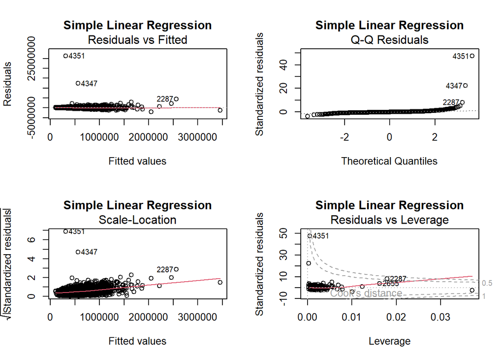

```r
par(mfrow=c(2,2))
plot(simplemodel, main = "Simple Linear Regression")
```

Multiple linear regression model:

```r
multimodel <- lm(price ~ ., data=houseTraining[,2:14])
summary(multimodel)
```

```
##
## Call:
## lm(formula = price ~ ., data = houseTraining[, 2:14])
##
## Residuals:
##      Min       1Q   Median       3Q      Max
## -2171427  -129906   -18830    85505 26331314
##
## Coefficients: (1 not defined because of singularities)
##                 Estimate Std. Error t value Pr(>|t|)
## (Intercept)    4.671e+06  8.357e+05   5.589 2.44e-08 ***
## bedrooms      -5.865e+04  1.290e+04  -4.547 5.62e-06 ***
## bathrooms      5.589e+04  2.073e+04   2.696  0.00705 **
## sqft_living    2.360e+02  2.618e+01   9.011  < 2e-16 ***
## sqft_lot      -8.065e-01  2.557e-01  -3.154  0.00163 **
## floors         3.987e+04  2.291e+04   1.740  0.08196 .
## waterfront     4.609e+05  1.153e+05   3.996 6.57e-05 ***
## view           4.319e+04  1.359e+04   3.179  0.00149 **
## condition      3.098e+04  1.584e+04   1.955  0.05063 .
## sqft_above     2.964e+01  2.597e+01   1.141  0.25388
## sqft_basement         NA         NA      NA       NA
## yr_built      -2.419e+03  4.168e+02  -5.804 7.02e-09 ***
## yr_renovated   3.495e+00  1.052e+01   0.332  0.73979
## ---
## Signif. codes:  0 '***' 0.001 '**' 0.01 '*' 0.05 '.' 0.1 ' ' 1
##
## Residual standard error: 544400 on 3679 degrees of freedom
## Multiple R-squared:  0.1986, Adjusted R-squared:  0.1963
## F-statistic: 82.91 on 11 and 3679 DF,  p-value: < 2.2e-16
```

Using this model to predict ‘price’ in houseTesting and calculate MAE and MSE .

```r
multiprice_prediction <-predict(object = multimodel, newdata = houseTesting)
summary(multiprice_prediction)
```

```
##    Min. 1st Qu.  Median    Mean 3rd Qu.    Max.
##   67478  381388  499551  555721  672009 1914077
```

```r
MAE(y_pred = multiprice_prediction, y_true = houseTesting$price)
```

```
## [1] 160351.8
```

```r
MSE(y_pred = multiprice_prediction, y_true = houseTesting$price)
```

```
## [1] 59128936714
```

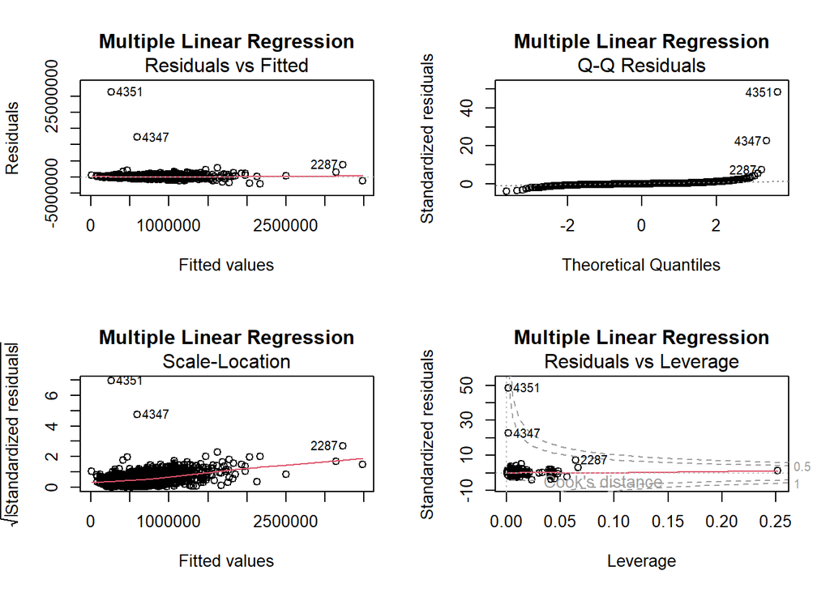

```r
par(mfrow=c(2,2))
plot(multimodel, main = "Multiple Linear Regression")
```

Subset Selection Linear Regression Model:

Forward Stepwise:

Begin with the null model — a model that contains an intercept but no predictors. Fit p simple linear regressions and add to the null model the variable that results in the lowest RSS. Add to that model the variable that results in the lowest RSS amongst all two-variable models. Continue until some stopping rule is satisfied, for example when all remaining variables have a p-value above some threshold.

```r
intercept_only <- lm(price ~ 1, data=houseTraining)
# Create a full model
all <- lm(price ~. , data=houseTraining[,2:14])
# perform forward step-wise regression
forward <- stepAIC (intercept_only, direction='forward',scope = formula(all))
```

```
## Start:  AIC=98304.86
## price ~ 1
##
##                 Df  Sum of Sq        RSS   AIC
## + sqft_living    1 2.2868e+14 1.1320e+15 97628
## + sqft_above     1 1.6914e+14 1.1916e+15 97817
## + bathrooms      1 1.3236e+14 1.2283e+15 97929
## + view           1 6.5018e+13 1.2957e+15 98126
## + sqft_basement  1 5.2879e+13 1.3078e+15 98161
## + bedrooms       1 5.0243e+13 1.3105e+15 98168
## + waterfront     1 2.9001e+13 1.3317e+15 98227
## + floors         1 2.8175e+13 1.3325e+15 98230
## + sqft_lot       1 3.4177e+12 1.3573e+15 98298
## + condition      1 1.4191e+12 1.3593e+15 98303
## + yr_renovated   1 1.3906e+12 1.3593e+15 98303
## + yr_built       1 7.6055e+11 1.3599e+15 98305
## <none>                        1.3607e+15 98305
##
## Step:  AIC=97627.72
## price ~ sqft_living
##
##                 Df  Sum of Sq        RSS   AIC
## + yr_built       1 1.3266e+13 1.1188e+15 97586
## + view           1 1.2089e+13 1.1199e+15 97590
## + waterfront     1 1.1696e+13 1.1203e+15 97591
## + bedrooms       1 6.1427e+12 1.1259e+15 97610
## + condition      1 4.6644e+12 1.1274e+15 97614
## + sqft_lot       1 2.9077e+12 1.1291e+15 97620
## <none>                        1.1320e+15 97628
## + yr_renovated   1 5.1376e+11 1.1315e+15 97628
## + sqft_above     1 4.2220e+11 1.1316e+15 97628
## + sqft_basement  1 4.2220e+11 1.1316e+15 97628
## + floors         1 1.9797e+10 1.1320e+15 97630
## + bathrooms      1 1.0177e+09 1.1320e+15 97630
##
## Step:  AIC=97586.21
## price ~ sqft_living + yr_built
##
##                 Df  Sum of Sq        RSS   AIC
## + waterfront     1 1.0052e+13 1.1087e+15 97555
```

[output cut: 83 more lines]

```
## + condition      1 1.0583e+12 1.0908e+15 97507
## <none>                        1.0919e+15 97508
## + sqft_above     1 2.8859e+11 1.0916e+15 97509
## + sqft_basement  1 2.8859e+11 1.0916e+15 97509
## + yr_renovated   1 4.8104e+10 1.0918e+15 97510
##
## Step:  AIC=97506.88
## price ~ sqft_living + yr_built + waterfront + bedrooms + bathrooms +
##     sqft_lot + view + floors + condition
##
##                 Df  Sum of Sq        RSS   AIC
## <none>                        1.0908e+15 97507
## + sqft_above     1 3.8510e+11 1.0904e+15 97508
## + sqft_basement  1 3.8510e+11 1.0904e+15 97508
## + yr_renovated   1 3.1834e+10 1.0908e+15 97509
```

```r
forward$anova
```

```
## Stepwise Model Path
## Analysis of Deviance Table
##
## Initial Model:
## price ~ 1
##
## Final Model:
## price ~ sqft_living + yr_built + waterfront + bedrooms + bathrooms +
##     sqft_lot + view + floors + condition
##
##
##             Step Df     Deviance Resid. Df   Resid. Dev      AIC
## 1                                     3690 1.360701e+15 98304.86
## 2  + sqft_living  1 2.286838e+14      3689 1.132017e+15 97627.72
## 3     + yr_built  1 1.326594e+13      3688 1.118751e+15 97586.21
## 4   + waterfront  1 1.005170e+13      3687 1.108699e+15 97554.90
## 5     + bedrooms  1 5.291435e+12      3686 1.103408e+15 97539.24
## 6    + bathrooms  1 4.301859e+12      3685 1.099106e+15 97526.82
## 7     + sqft_lot  1 2.950870e+12      3684 1.096155e+15 97518.90
## 8         + view  1 2.879453e+12      3683 1.093276e+15 97511.19
## 9       + floors  1 1.399767e+12      3682 1.091876e+15 97508.46
## 10   + condition  1 1.058342e+12      3681 1.090818e+15 97506.88
```

```r
summary(forward)
```

```
##
## Call:
## lm(formula = price ~ sqft_living + yr_built + waterfront + bedrooms +
##     bathrooms + sqft_lot + view + floors + condition, data = houseTraining)
##
## Residuals:
##      Min       1Q   Median       3Q      Max
## -2121038  -129098   -17864    87175 26337370
##
## Coefficients:
##               Estimate Std. Error t value Pr(>|t|)
## (Intercept)  4.640e+06  7.710e+05   6.019 1.93e-09 ***
## sqft_living  2.597e+02  1.602e+01  16.208  < 2e-16 ***
## yr_built    -2.397e+03  3.894e+02  -6.156 8.25e-10 ***
## waterfront   4.600e+05  1.153e+05   3.988 6.79e-05 ***
## bedrooms    -5.926e+04  1.287e+04  -4.606 4.25e-06 ***
## bathrooms    5.200e+04  2.047e+04   2.541  0.01110 *
## sqft_lot    -7.757e-01  2.540e-01  -3.054  0.00228 **
## view         4.116e+04  1.344e+04   3.062  0.00221 **
## floors       4.996e+04  2.055e+04   2.431  0.01511 *
## condition    2.769e+04  1.465e+04   1.890  0.05886 .
## ---
## Signif. codes:  0 '***' 0.001 '**' 0.01 '*' 0.05 '.' 0.1 ' ' 1
##
## Residual standard error: 544400 on 3681 degrees of freedom
## Multiple R-squared:  0.1983, Adjusted R-squared:  0.1964
## F-statistic: 101.2 on 9 and 3681 DF,  p-value: < 2.2e-16
```

Using this model to predict price in houseTesting and calculate MAE and MSE.

```r
houseTesting$price <- as.numeric(as.character(houseTesting$price))
```

```r
pred_forward <-predict(object = forward, newdata = houseTesting)
summary(pred_forward)
```

```
##    Min. 1st Qu.  Median    Mean 3rd Qu.    Max.
##   75982  378628  501809  555878  675227 1928987
```

```r
MAE(y_pred = pred_forward, y_true = houseTesting$price)
```

```
## [1] 160194.1
```

```r
MSE(y_pred = pred_forward, y_true = houseTesting$price)
```

```
## [1] 59296290093
```

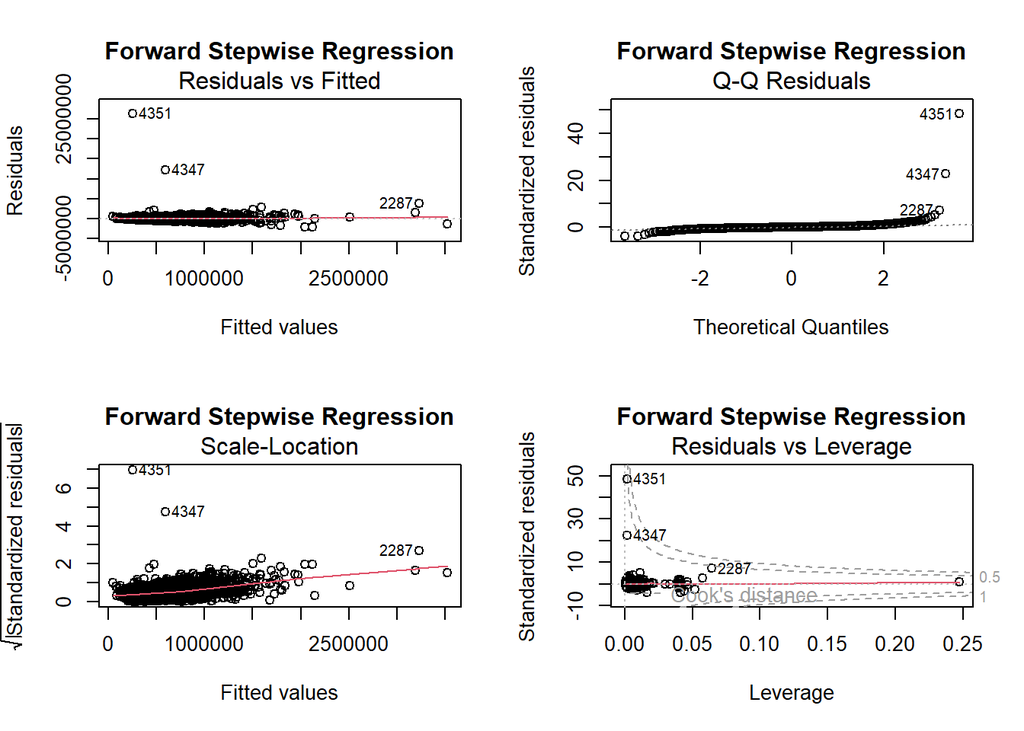

```r
par(mfrow=c(2,2))
plot(forward, main = "Forward Stepwise Regression")
```

Backward Stepwise:

```r
backward <- stepAIC (all, direction='backward')
```

```
## Start:  AIC=97509.47
## price ~ bedrooms + bathrooms + sqft_living + sqft_lot + floors +
##     waterfront + view + condition + sqft_above + sqft_basement +
##     yr_built + yr_renovated
##
##
## Step:  AIC=97509.47
## price ~ bedrooms + bathrooms + sqft_living + sqft_lot + floors +
##     waterfront + view + condition + sqft_above + yr_built + yr_renovated
##
##                Df  Sum of Sq        RSS   AIC
## - yr_renovated  1 3.2700e+10 1.0904e+15 97508
## - sqft_above    1 3.8596e+11 1.0908e+15 97509
## <none>                       1.0904e+15 97509
## - floors        1 8.9724e+11 1.0913e+15 97511
## - condition     1 1.1331e+12 1.0915e+15 97511
## - bathrooms     1 2.1542e+12 1.0926e+15 97515
## - sqft_lot      1 2.9475e+12 1.0933e+15 97517
## - view          1 2.9947e+12 1.0934e+15 97518
## - waterfront    1 4.7327e+12 1.0951e+15 97523
## - bedrooms      1 6.1272e+12 1.0965e+15 97528
## - yr_built      1 9.9846e+12 1.1004e+15 97541
## - sqft_living   1 2.4067e+13 1.1145e+15 97588
##
## Step:  AIC=97507.58
## price ~ bedrooms + bathrooms + sqft_living + sqft_lot + floors +
##     waterfront + view + condition + sqft_above + yr_built
##
##               Df  Sum of Sq        RSS   AIC
## - sqft_above   1 3.8510e+11 1.0908e+15 97507
## <none>                      1.0904e+15 97508
## - floors       1 8.6828e+11 1.0913e+15 97509
## - condition    1 1.1548e+12 1.0916e+15 97509
## - bathrooms    1 2.1386e+12 1.0926e+15 97513
## - sqft_lot     1 2.9634e+12 1.0934e+15 97516
## - view         1 3.0215e+12 1.0935e+15 97516
## - waterfront   1 4.7301e+12 1.0952e+15 97522
## - bedrooms     1 6.0989e+12 1.0965e+15 97526
## - yr_built     1 1.1603e+13 1.1020e+15 97545
## - sqft_living  1 2.4089e+13 1.1145e+15 97586
##
## Step:  AIC=97506.88
## price ~ bedrooms + bathrooms + sqft_living + sqft_lot + floors +
##     waterfront + view + condition + yr_built
##
##               Df  Sum of Sq        RSS   AIC
## <none>                      1.0908e+15 97507
## - condition    1 1.0583e+12 1.0919e+15 97508
## - floors       1 1.7512e+12 1.0926e+15 97511
## - bathrooms    1 1.9131e+12 1.0927e+15 97511
## - sqft_lot     1 2.7633e+12 1.0936e+15 97514
## - view         1 2.7791e+12 1.0936e+15 97514
## - waterfront   1 4.7131e+12 1.0955e+15 97521
## - bedrooms     1 6.2858e+12 1.0971e+15 97526
## - yr_built     1 1.1231e+13 1.1020e+15 97543
## - sqft_living  1 7.7847e+13 1.1687e+15 97759
```

```r
backward$anova
```

```
## Stepwise Model Path
## Analysis of Deviance Table
##
## Initial Model:
## price ~ bedrooms + bathrooms + sqft_living + sqft_lot + floors +
##     waterfront + view + condition + sqft_above + sqft_basement +
##     yr_built + yr_renovated
##
## Final Model:
## price ~ bedrooms + bathrooms + sqft_living + sqft_lot + floors +
##     waterfront + view + condition + yr_built
##
##
##              Step Df     Deviance Resid. Df   Resid. Dev      AIC
## 1                                      3679 1.090400e+15 97509.47
## 2 - sqft_basement  0            0      3679 1.090400e+15 97509.47
## 3  - yr_renovated  1  32700349012      3680 1.090433e+15 97507.58
## 4    - sqft_above  1 385095472744      3681 1.090818e+15 97506.88
```

```r
summary(backward)
```

```
##
## Call:
## lm(formula = price ~ bedrooms + bathrooms + sqft_living + sqft_lot +
##     floors + waterfront + view + condition + yr_built, data = houseTraining[,
##     2:14])
##
## Residuals:
##      Min       1Q   Median       3Q      Max
## -2121038  -129098   -17864    87175 26337370
##
## Coefficients:
##               Estimate Std. Error t value Pr(>|t|)
## (Intercept)  4.640e+06  7.710e+05   6.019 1.93e-09 ***
## bedrooms    -5.926e+04  1.287e+04  -4.606 4.25e-06 ***
## bathrooms    5.200e+04  2.047e+04   2.541  0.01110 *
## sqft_living  2.597e+02  1.602e+01  16.208  < 2e-16 ***
## sqft_lot    -7.757e-01  2.540e-01  -3.054  0.00228 **
## floors       4.996e+04  2.055e+04   2.431  0.01511 *
## waterfront   4.600e+05  1.153e+05   3.988 6.79e-05 ***
## view         4.116e+04  1.344e+04   3.062  0.00221 **
## condition    2.769e+04  1.465e+04   1.890  0.05886 .
## yr_built    -2.397e+03  3.894e+02  -6.156 8.25e-10 ***
## ---
## Signif. codes:  0 '***' 0.001 '**' 0.01 '*' 0.05 '.' 0.1 ' ' 1
##
## Residual standard error: 544400 on 3681 degrees of freedom
## Multiple R-squared:  0.1983, Adjusted R-squared:  0.1964
## F-statistic: 101.2 on 9 and 3681 DF,  p-value: < 2.2e-16
```

Using this model to predict price in houseTesting and calculate MAE and MSE.

```r
pred_backward <-predict(object = backward, newdata = houseTesting)
summary(pred_backward)
```

```
##    Min. 1st Qu.  Median    Mean 3rd Qu.    Max.
##   75982  378628  501809  555878  675227 1928987
```

```r
MAE(y_pred = pred_backward, y_true = houseTesting$price)
```

```
## [1] 160194.1
```

```r
MSE(y_pred = pred_backward, y_true = houseTesting$price)
```

```
## [1] 59296290093
```

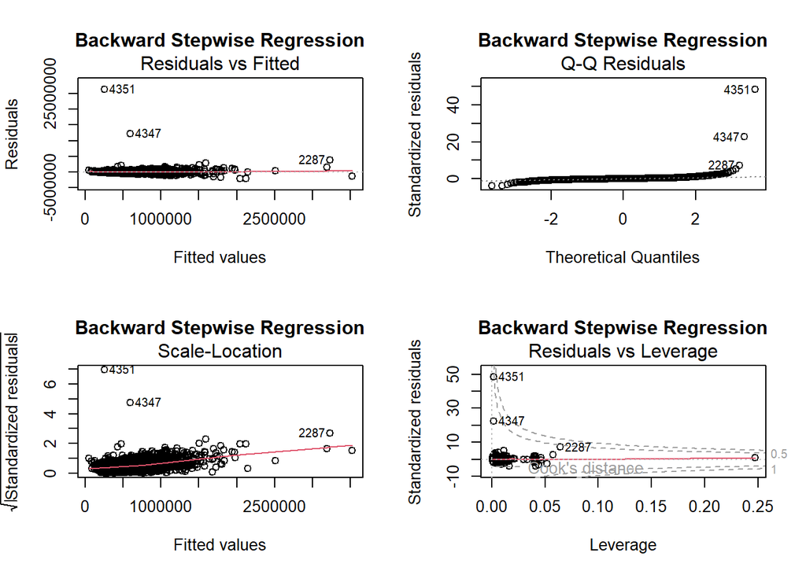

```r
par(mfrow=c(2,2))
plot(backward, main = "Backward Stepwise Regression")
```

Comparing all the linear regression models:

If R^2 is greater indicates better model fit, measures the Proportion of variance depicted by model for adjusted number of predictors.

RSE provides an absolute measure of lack of fit, lower value will be a better fit MAE is the avg absolute difference between the Actual values and Predictors. if MAE is lower indicates better model fit.

MSE is the avg Squared difference between the Actual values and Predictors. if MSE is lower indicates better model fit.

Forward Subset and Backward subset selection have the same results(RSE,MAE,MSE,R^2 )